# Chapter 2 - Small worlds and large worlds

Modeling constructs a small world which we hope can extrapolate well to the large world. Bayesian models claim optimality: No alternative model could make better use of the information in the data and support better decisions, assuming the small world is an accurate description of the real world.

# The garden of forking data

Bayesian inference boils down to counting the possible ways your evidence could have come true.

## Counting possibliity

Suppose we have a bag full of four blue or white marbles. We have drawn 3 marbles with replacement and seen {B, W, B}. We are interested in estimating what proportion of the bag is blue. The bayesian answers this question by enumerating all the possible states of our parameter, {$\frac{0}{4}$, $\frac{1}{4}$, $\frac{2}{4}$, $\frac{3}{4}$, $\frac{4}{4}$}, and seeing which one was most likely to generate our answer.

For example, consider the state $proportion = \frac{1}{4}$. Because the bag contains four marbles, each draw has four potential states. Because there were three draws, we have $4^3 = 64$ potential states in total. The next question is, how many of those states are reflective of the evidence we saw, {B, W, B}? Given four marbles, {B1, W1, W2, W3}, here are the possiblities:

```
[B1, W1, B1]
[B1, W2, B1]
[B1, W3, B1]
```

Therefore, we believe proportion has a $\frac{3}{64}$ likelihood of being true given our evidence. We can calculate this similarly for the other potential values of our parameter and choose the most likely one.

## Using prior information

Perhaps we’ve had some draws in the past giving us some prior information on what we’ve seen before. Bayesians can use prior information to help constrain the likelihoods generated off of new data. Another way of saying this is that we can simply updated our prior information with our new learned likelihoods. This new updated probability is known as the `posterior probability`.

$$posterior probability \propto prior probability \times likelihood$$

## Summary

We needed to count three things to make this work. 1. The number of ways each conjecture could produce an observation 2. The accumulated number of ways each conjecture could produce the entire data 3. The initial plausibility of each conjectured cause of the data.

These translate to: 1. A likelihood function 2. One or more parameters 3. A prior.

- Parameter: The conjectured variable of interest, for example, the number of blue balls in a bag.
- Likelihood: The relative number of ways that a value `p` can produce the data. It is derived by enumerating all the possible data sequences that could have happened and then eliminating those sequences inconsistent with the data. This number is then normalized by dividing by all number of all possible sequences.
- Prior probability: The prior plausability of `p`.
- Posterior probablity: New updated plausbility of any specific `p`. Given by multiplying the prior with the likelihood.

## Grid Approximation

1. Define the grid. How many points to use in estimating the posterior? Represents a list of possible paramter values.
2. Compute the value of the prior at each parameter value on the grid.
3. Compute the likelihood at each parameter value.
4. Compute the unstandardized posterior at each parameter value, by multiplying the prior by the likelihood.

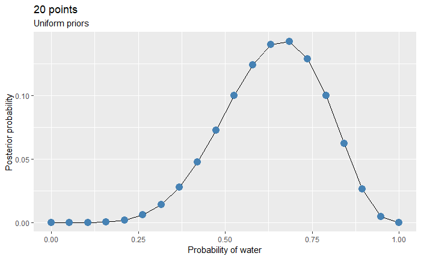

```r
# define grid of possible paramter values.
p_grid <- seq(from=0, to=1, length.out = 20)

# Define priors
prior <- rep(1, 20)

# compute likelihood at each value in grid
likelihood <- dbinom(6, size = 9, prob = p_grid)

# Compute product of likelihood and prior
unstd_posterior <- likelihood * prior

# Standardize the posterior, so it sums to 1
posterior <- unstd_posterior / sum(unstd_posterior)

# Plot the results
tibble(p_grid, posterior) %>%
  ggplot(aes(p_grid, posterior)) +
  geom_line() +
  geom_point(size=4, colour="steelblue", fill="blue") +
  xlab("Probability of water") + ylab("Posterior probability") +
  ggtitle("20 points", "Uniform priors")
```

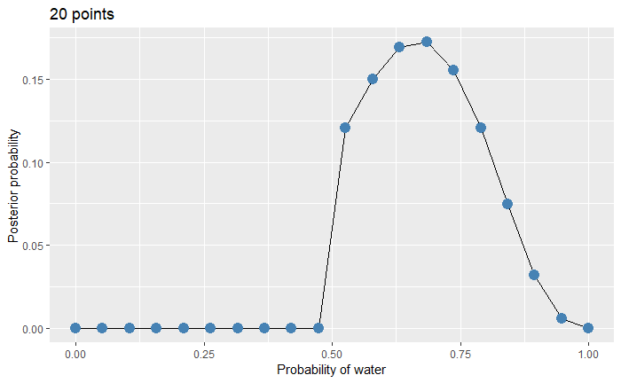

```r
# define grid of possible paramter values.
p_grid <- seq(from=0, to=1, length.out = 20)

# Define priors
prior <- ifelse(p_grid < .5, 0, 1)

# compute likelihood at each value in grid
likelihood <- dbinom(6, size = 9, prob = p_grid)

# Compute product of likelihood and prior
unstd_posterior <- likelihood * prior

# Standardize the posterior, so it sums to 1
posterior <- unstd_posterior / sum(unstd_posterior)

# Plot the results
tibble(p_grid, posterior) %>%
  ggplot(aes(p_grid, posterior)) +
  geom_line() +
  geom_point(size=4, colour="steelblue", fill="blue") +
  xlab("Probability of water") + ylab("Posterior probability") +
  ggtitle("20 points")
```

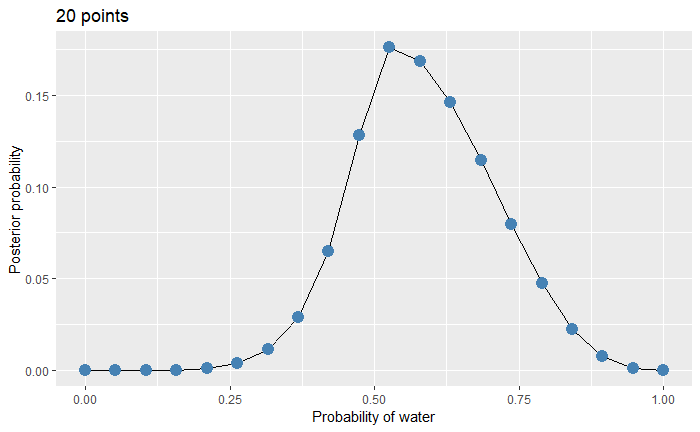

```r
# define grid of possible paramter values.
p_grid <- seq(from=0, to=1, length.out = 20)

# Define priors, here we assume uniform.
prior <- exp(-5 * abs(p_grid - .5))

# compute likelihood at each value in grid
likelihood <- dbinom(6, size = 9, prob = p_grid)

# Compute product of likelihood and prior
unstd_posterior <- likelihood * prior

# Standardize the posterior, so it sums to 1
posterior <- unstd_posterior / sum(unstd_posterior)

# Plot the results
tibble(p_grid, posterior) %>%
  ggplot(aes(p_grid, posterior)) +
  geom_line() +
  geom_point(size=4, colour="steelblue", fill="blue") +
  xlab("Probability of water") + ylab("Posterior probability") +
  ggtitle("20 points")
```

## Quadratic approximation

It is very fast for common procedures such as linear regression.

1. Gradient descent to find peak.
2. Estimate the curvature at the peak, which is sufficient to compute the entire posterior distribution.

```r
library(rethinking)
globe_qa <- map(
  alist(
    w ~ dbinom(9, p),
    p ~ dunif(0, 1)
  ),
  data = list(w=6)
)

precis(globe_qa)
```

|  | Mean | StdDev | 5.5% | 94.5% |
| --- | --- | --- | --- | --- |
| p | 0.67 | 0.16 | 0.42 | 0.92 |

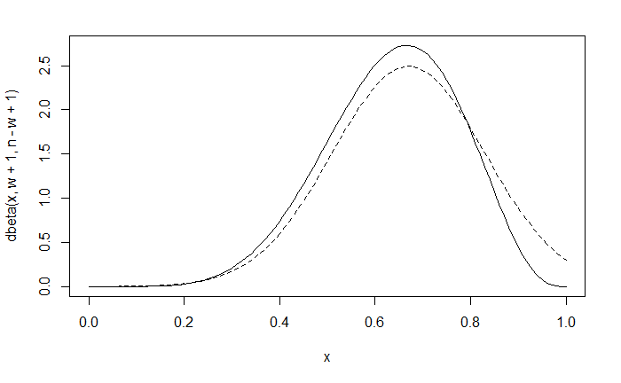

```r
# Analytical calculation
w <- 6
n <- 9
curve(dbeta(x, w+1, n-w+1), from=0, to=1)
curve(dnorm(x, .67, .16), lty=2, add=TRUE)
```

# Homework

## 2E1

2

## 2E2

3

## 2E3

1

## 2M1

1. W, W, W

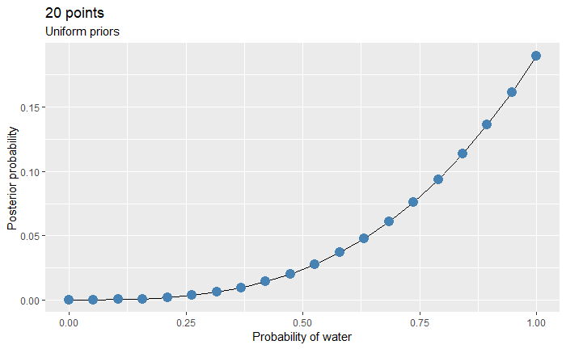

```r
# define grid of possible paramter values.
p_grid <- seq(from=0, to=1, length.out = 20)

# Define priors
prior <- rep(1, 20)

# compute likelihood at each value in grid
likelihood <- dbinom(3, size = 3, prob = p_grid)

# Compute product of likelihood and prior
unstd_posterior <- likelihood * prior

# Standardize the posterior, so it sums to 1
posterior <- unstd_posterior / sum(unstd_posterior)

# Plot the results
tibble(p_grid, posterior) %>%
  ggplot(aes(p_grid, posterior)) +
  geom_line() +
  geom_point(size=4, colour="steelblue", fill="blue") +
  xlab("Probability of water") + ylab("Posterior probability") +
  ggtitle("20 points", "Uniform priors")
```

2. W, W, W, L

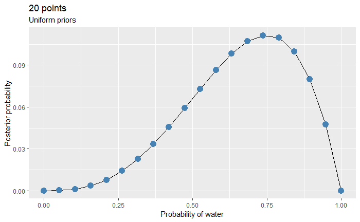

```r
# define grid of possible paramter values.
p_grid <- seq(from=0, to=1, length.out = 20)

# Define priors
prior <- rep(1, 20)

# compute likelihood at each value in grid
likelihood <- dbinom(3, size = 4, prob = p_grid)

# Compute product of likelihood and prior
unstd_posterior <- likelihood * prior

# Standardize the posterior, so it sums to 1
posterior <- unstd_posterior / sum(unstd_posterior)

# Plot the results
tibble(p_grid, posterior) %>%
  ggplot(aes(p_grid, posterior)) +
  geom_line() +
  geom_point(size=4, colour="steelblue", fill="blue") +
  xlab("Probability of water") + ylab("Posterior probability") +
  ggtitle("20 points", "Uniform priors")
```

3. L, W, W, L, W, W, W

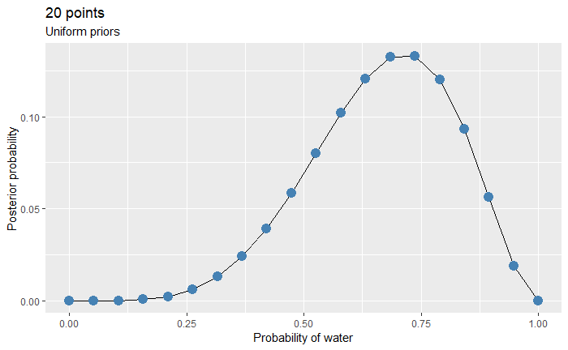

```r
# define grid of possible paramter values.
p_grid <- seq(from=0, to=1, length.out = 20)

# Define priors
prior <- rep(1, 20)

# compute likelihood at each value in grid
likelihood <- dbinom(5, size = 7, prob = p_grid)

# Compute product of likelihood and prior
unstd_posterior <- likelihood * prior

# Standardize the posterior, so it sums to 1
posterior <- unstd_posterior / sum(unstd_posterior)

# Plot the results
tibble(p_grid, posterior) %>%
  ggplot(aes(p_grid, posterior)) +
  geom_line() +
  geom_point(size=4, colour="steelblue", fill="blue") +
  xlab("Probability of water") + ylab("Posterior probability") +
  ggtitle("20 points", "Uniform priors")
```

## 2M2

1. W, W, W

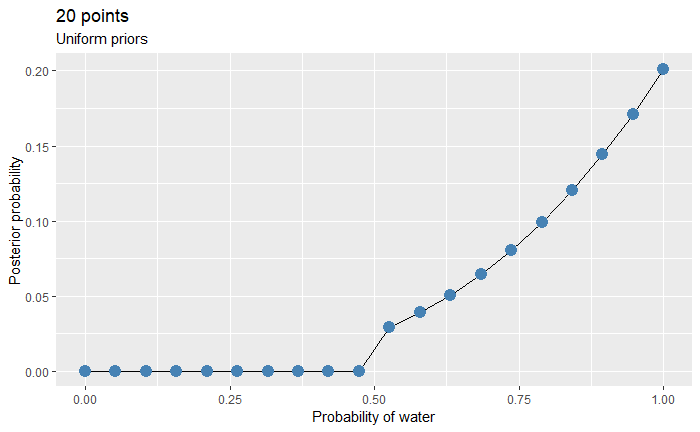

```r
# define grid of possible paramter values.
p_grid <- seq(from=0, to=1, length.out = 20)

# Define priors
prior <- ifelse(p_grid < .5, 0, 1)

# compute likelihood at each value in grid
likelihood <- dbinom(3, size = 3, prob = p_grid)

# Compute product of likelihood and prior
unstd_posterior <- likelihood * prior

# Standardize the posterior, so it sums to 1
posterior <- unstd_posterior / sum(unstd_posterior)

# Plot the results
tibble(p_grid, posterior) %>%
  ggplot(aes(p_grid, posterior)) +
  geom_line() +
  geom_point(size=4, colour="steelblue", fill="blue") +
  xlab("Probability of water") + ylab("Posterior probability") +
  ggtitle("20 points", "Uniform priors")
```

2. W, W, W, L

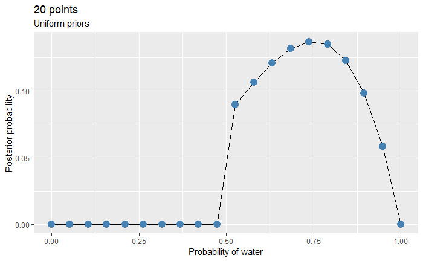

```r
# define grid of possible paramter values.
p_grid <- seq(from=0, to=1, length.out = 20)

# Define priors
prior <- ifelse(p_grid < .5, 0, 1)

# compute likelihood at each value in grid
likelihood <- dbinom(3, size = 4, prob = p_grid)

# Compute product of likelihood and prior
unstd_posterior <- likelihood * prior

# Standardize the posterior, so it sums to 1
posterior <- unstd_posterior / sum(unstd_posterior)

# Plot the results
tibble(p_grid, posterior) %>%
  ggplot(aes(p_grid, posterior)) +
  geom_line() +
  geom_point(size=4, colour="steelblue", fill="blue") +
  xlab("Probability of water") + ylab("Posterior probability") +
  ggtitle("20 points", "Uniform priors")
```

3. L, W, W, L, W, W, W

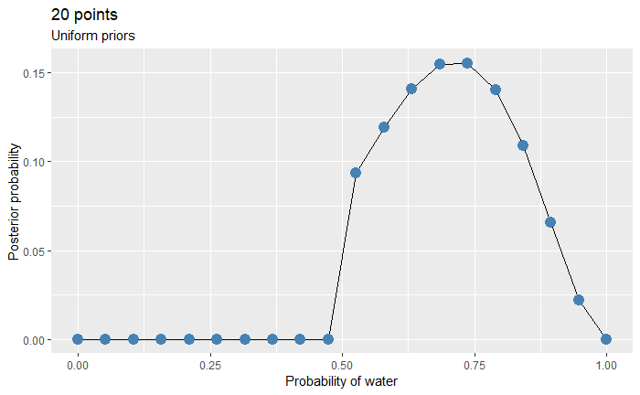

```r
# define grid of possible paramter values.
p_grid <- seq(from=0, to=1, length.out = 20)

# Define priors
prior <- ifelse(p_grid < .5, 0, 1)

# compute likelihood at each value in grid
likelihood <- dbinom(5, size = 7, prob = p_grid)

# Compute product of likelihood and prior
unstd_posterior <- likelihood * prior

# Standardize the posterior, so it sums to 1
posterior <- unstd_posterior / sum(unstd_posterior)

# Plot the results
tibble(p_grid, posterior) %>%
  ggplot(aes(p_grid, posterior)) +
  geom_line() +
  geom_point(size=4, colour="steelblue", fill="blue") +
  xlab("Probability of water") + ylab("Posterior probability") +
  ggtitle("20 points", "Uniform priors")
```

## 2M3

```r
prior_planet <- c(earth=.5, mars=.5)
likelihood_land <- c(earth=.3, mars=1)
unstandardized_posterior <- prior_planet * likelihood_land
posterior = unstandardized_posterior / sum(unstandardized_posterior)

posterior["earth"]
```

```
    earth
0.2307692
```

## 2M4

```r
prior <- rep(1, 3)
likelihood <- c(c1=2, c2=1, c3=0)
```